# YAPAY SİNİR AĞLARI - DESTEK VEKTÖRLERİ

Tarık Çelik

2021-07-12

# **YAPAY SINIR AGLARI (INTEGER)**

[figure not shown]

## **GEREKLI KUTUPHANELER VE VERININ OKUTULMASI**

```r
library(plotly)
library(ggplot2)
library(faraway)
library(lmtest)
library(car)
library(readxl)
library(corrplot)
library(psych)
library(neuralnet)
library(caret)
library(e1071)
library(caTools)

cars=read_excel("C:/Users/Tarık/Desktop/Ders Notlarım/4. Sınıf/1. Dönem/Veri Madenciliği/VİZE/car_consumption.xls")
```

- **Kaynak:** http://data-mining-tutorials.blogspot.com/2010/05/solutions-for-multicollinearity-in.html
- **Aciklama:** Farkli model arabalarin ozellikleri verilmistir.

**Bagimli Degisken :**

- **Price:** Arabanin fiyati

**Aciklayici Degiskenler:**

- **Cylinder:** Arabanin silindir hacmi
- **Power:** Arabanin gucu (beygiri)
- **Weight:** Arabanin agirligi
- **Consumption:** Yakit tuketimi
- **Gozlem Sayisi:** 27
- **Aciklayici Degisken Sayisi:** 4

```r
cars1=cars[,-1]
apply(cars1,2,function(x) sum(is.na(x)))
```

```
##       Price    Cylinder       Power      Weight Consumption
##           0           0           0           0           0
```

- *Kategorik degiskeni cikarip veride eksik gozlem olup olmadigina baktik. Olmadigini gorduk.*

```r
maxs=apply(cars1,2,max)
mins=apply(cars1,2,min)

scaled=as.data.frame(scale(cars1, center=mins, scale=maxs-mins))
head(scaled)
```

```
##        Price  Cylinder      Power     Weight Consumption
## 1 0.02843016 0.0812446 0.02479339 0.00000000  0.00000000
## 2 0.05043263 0.1447710 0.08264463 0.12173913  0.01408451
## 3 0.00000000 0.1041487 0.00000000 0.06956522  0.05633803
## 4 0.16538937 0.3163354 0.12396694 0.26521739  0.11267606
## 5 0.10815822 0.2320657 0.03305785 0.21304348  0.15492958
## 6 0.08108776 0.0000000 0.02479339 0.07826087  0.15492958
```

- *Min max normalizasyonu yaptik. Verinin bu halini test ve train olusturmak icin kullanacagiz.*

```r
index=sample(1:nrow(cars1),round(0.75*nrow(cars1)))
train=scaled[index,]
test=scaled[-index,]
```

- *Verinin %75’ini train, kalan kismini test olarak belirledik.*

```r
set.seed(1234)
n=names(train) #traindeki degiskenlerin isimlerini aliyor.
f=as.formula(paste("Price ~", paste(n[!n %in% "Price"], collapse = " + ")))
nn=neuralnet(f,data=train,hidden=2,linear.output=T)
plot(nn)
```

- *Neuralnet kurmus olduk. Hidden degisken sayisinin 2/3’u kadar olacagindan 2 olarak belirledim.*
- *Linear.output:T olmasi gerekiyor cunku surekli bir veriyle calisiyoruz.*
- **Html ciktisinda plot gozukmuyor. Bunun sebebini anlayamadigim icin fotograf olarak ekledim:**

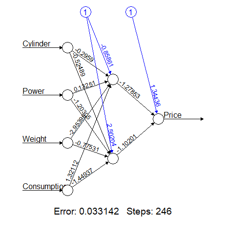

- *Bundan sonraki adimda yanit degiskenini disarda birakip normalizasyonu tersine cevirmemiz gerekiyor.*

```r
pr.nn=compute(nn,test[,2:5])
```

```r
pr.nn=pr.nn$net.result*(max(cars1$Price)-min(cars1$Price))+min(cars1$Price)
pr.nn
```

```
##        [,1]
## 1  10425.37
## 5  15670.98
## 7  18725.72
## 9  25012.58
## 11 27394.98
## 19 44250.01
## 22 45437.26
```

- *Burada dikkat etmemiz gereken sey negatif degerler. Bu islemin sonunda orjinal verimizde olmamasina ragmen negatif degerler cikabilirdi. Bende cikmadigi icin devam edebilirim.*
- *Ayrica bu degerler orjinal tahminlerim oluyor.*

```r
MSE.nn <- sum((cars1[-index,]$Price - pr.nn)^2)/nrow(test)
MSE.nn
```

```
## [1] 9502475
```

- *Mean squared error degerime ulasmis oldum.*

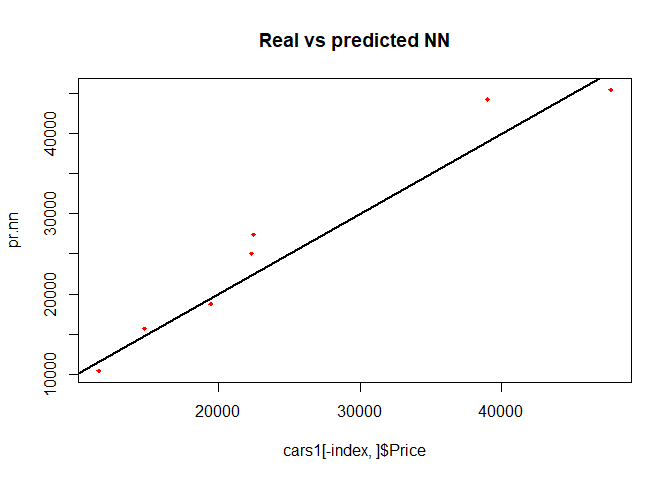

```r
plot(cars1[-index,]$Price, pr.nn, col='red', main='Real vs predicted NN', pch=18, cex=0.7)
abline(0,1,lwd=2)
```

- *Bu grafik ile gercek degerler ve tahmin edilen degerleri gormus oluyoruz.*
- *Verimiz nispeten kucuk bir veri oldugu icin 7 gozlem iceren bir test verisine sahibiz. Bu yuzden grafigin boyle olmasi dogal.*

# **YAPAY SINIR AGLARI (CLASSIFICATION)**

## **VERIYI OKUTMAK VE DUZENLEMEK**

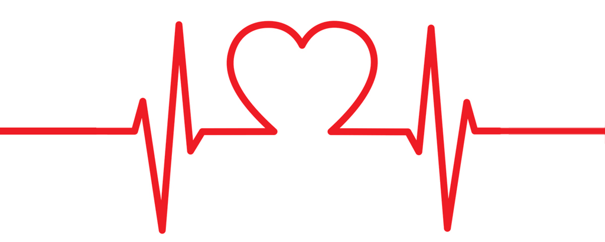

```r
data=read.csv("C:/Users/Tarık/Desktop/Ders Notlarım/4. Sınıf/1. Dönem/Veri Madenciliği/VİZE/heart.csv")
```

- **Veride benim ilgilendigim degiskenleri secip, hatalari duzenleyerek kullanima hazir hale getirecegim.**

```r
data$age=data$ï..age
heart=select(data,age,trestbps,chol,thalach,oldpeak,target)
heart$target=as.factor(heart$target)

str(heart)
```

```
## 'data.frame':    303 obs. of  6 variables:
##  $ age     : int  63 37 41 56 57 57 56 44 52 57 ...
##  $ trestbps: int  145 130 130 120 120 140 140 120 172 150 ...
##  $ chol    : int  233 250 204 236 354 192 294 263 199 168 ...
##  $ thalach : int  150 187 172 178 163 148 153 173 162 174 ...
##  $ oldpeak : num  2.3 3.5 1.4 0.8 0.6 0.4 1.3 0 0.5 1.6 ...
##  $ target  : Factor w/ 2 levels "0","1": 2 2 2 2 2 2 2 2 2 2 ...
```

- **Kaynak:** https://www.kaggle.com/ronitf/heart-disease-uci
- **Aciklama:** Hastada kalp hastaliginin varligini anlamak bu veri setinin amacidir.

**Yanit Degiskeni :**

- **target:** Hastaligi var mi yok mu (Evet=1, Hayir=0)

**Bagimli Degiskenler:**

- **age:** Hastanin yasi
- **trestbps:** Kan basinci
- **chol:** mg/dl cinsinden serum kolesterol
- **thalach:** Ulasilan maksimum kalp atıs hizi
- **oldpeak:** Dinlenmeye gore egzersizin neden oldugu ST depresyonu
- **Gozlem Sayisi:** 303
- **Aciklayici Degisken Sayisi:** 5

## **EKSIK GOZLEMLERIN BELIRLENMESI**

```r
summary(heart)
```

```
##       age           trestbps          chol          thalach         oldpeak
##  Min.   :29.00   Min.   : 94.0   Min.   :126.0   Min.   : 71.0   Min.   :0.00
##  1st Qu.:47.50   1st Qu.:120.0   1st Qu.:211.0   1st Qu.:133.5   1st Qu.:0.00
##  Median :55.00   Median :130.0   Median :240.0   Median :153.0   Median :0.80
##  Mean   :54.37   Mean   :131.6   Mean   :246.3   Mean   :149.6   Mean   :1.04
##  3rd Qu.:61.00   3rd Qu.:140.0   3rd Qu.:274.5   3rd Qu.:166.0   3rd Qu.:1.60
##  Max.   :77.00   Max.   :200.0   Max.   :564.0   Max.   :202.0   Max.   :6.20
##  target
##  0:138
##  1:165
##
##
##
##
```

```r
apply(heart,2,function(x) sum(is.na(x)))
```

```
##      age trestbps     chol  thalach  oldpeak   target
##        0        0        0        0        0        0
```

# **YSA UYGULAMASI**

```r
maxs=apply(heart[ ,1:5], 2, max) #Sutunlarin max degeri
mins=apply(heart[ ,1:5], 2, min) #Sutunlarin min degeri
scaled=data.frame(as.data.frame(scale(heart[,1:5], center=mins, scale=maxs-mins)),heart$target)
```

- *Verimizde ki numerik degiskenlere min-max normalizasyonu yaptik.*

```r
set.seed(1234)
index=sample(1:nrow(heart),round(0.75*nrow(heart)))
train=scaled[index,]
test=scaled[-index,]
```

- *Bu islemde de test ve train verilerimizi olusturuyoruz. (%75 train, %25 test olacak sekilde)*

```r
nntrain=train

nntrain=cbind(nntrain, train$heart.target == 1)
nntrain=cbind(nntrain, train$heart.target == 0)
names(nntrain)[7]='evet'
names(nntrain)[8]='hayir'
head(nntrain)
```

```
##           age  trestbps      chol   thalach    oldpeak heart.target  evet hayir
## 284 0.2291667 0.5471698 0.2214612 0.8396947 0.00000000            0 FALSE  TRUE
## 101 0.2708333 0.5094340 0.2694064 0.8167939 0.12903226            1  TRUE FALSE
## 111 0.7291667 0.8113208 0.4543379 0.6335878 0.00000000            1  TRUE FALSE
## 133 0.2708333 0.2452830 0.3858447 0.6946565 0.00000000            1  TRUE FALSE
## 98  0.4791667 0.1320755 0.2442922 0.5801527 0.01612903            1  TRUE FALSE
## 103 0.7083333 0.4339623 0.1575342 0.8244275 0.00000000            1  TRUE FALSE
```

- *Kategorik bir aciklayici degisken ile calistigimiz icin yukaridaki islemi yapmaliyiz.*
- *Cunku target degiskenimiz kategorik olarak ikiye ayrilmis ve cikti katmanindaki noron sayisi buna bagli olacaktir.*

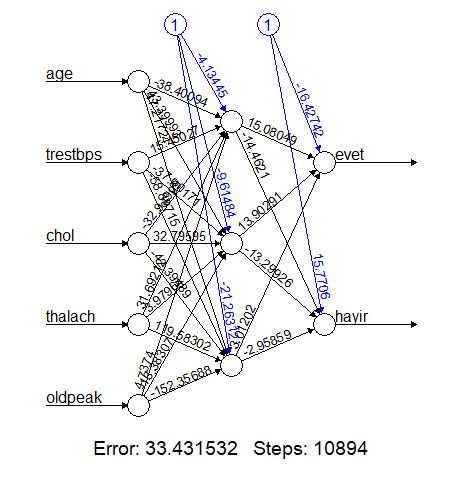

```r
set.seed(1234)
library(neuralnet)
ANN=neuralnet(evet+hayir ~ age+trestbps+chol+thalach+oldpeak, data=nntrain, hidden=3, linear.output=F)
plot(ANN)
```

- *Degisken sayisi 5 oldugundan hidden=3 aldim. (2/3)*
- *linear.output=F kategorik olmasindan kaynaklidir.*
- *Bu plot sayesinde error ve bias degerlerine ulasabiliyoruz.*
- **Simdi tahmin degerleri ile predict olusturuyoruz. Yanit degiskenine normalizasyon yapmadigimiz icin geri donmemize gerek yok.**
- **Tahmin degerleri >0.5 olanlar hasta, olmayanlar hasta degil olacaktir.**

```r
pred = ifelse((predict(ANN,test)>0.5)[,1]=="TRUE","1","0")
```

# **CONFUSION MATRIX**

- **Confusion matrix sayesinde butun degerlere tek bir tablo uzerinden ulasabiliyoruz. Gayet kullanisli.**

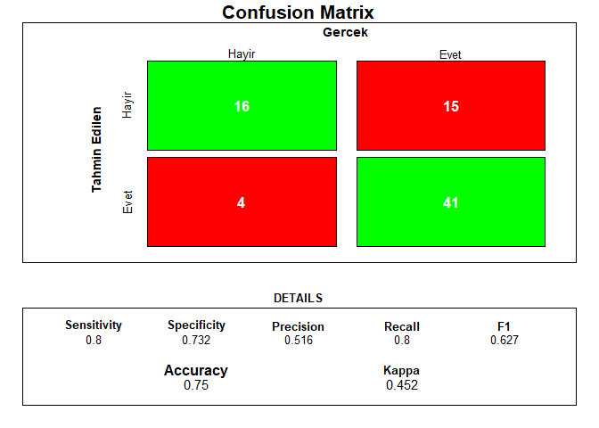

```r
cm <- confusionMatrix(table(test[,6], pred))

draw_confusion_matrix <- function(cm) {
  layout(matrix(c(1,1,2)))
  par(mar=c(2,2,2,2))
  plot(c(100, 345), c(300, 450), type = "n", xlab="", ylab="", xaxt='n', yaxt='n')
  title('Confusion Matrix', cex.main = 2)

  rect(150, 430, 240, 370, col = 'green')
  text(195, 435, 'Hayir', cex = 1.2)
  rect(250, 430, 340, 370, col = 'red')
  text(295, 435, 'Evet', cex = 1.2)
  text(125, 370, 'Tahmin Edilen', cex = 1.3, srt = 90, font = 2)
  text(245, 450, 'Gercek', cex=1.3, font=2)
  rect(150, 305, 240, 365, col = 'red')
  rect(250, 305, 340, 365, col = 'green')
  text(140, 400, 'Hayir', cex = 1.2, srt = 90)
  text(140, 335, 'Evet', cex = 1.2, srt = 90)

  res <- as.numeric(cm$table)
  text(195, 400, res[1], cex = 1.6, font = 2, col = 'white')
  text(195, 335, res[2], cex = 1.6, font = 2, col = 'white')
  text(295, 400, res[3], cex = 1.6, font = 2, col = 'white')
  text(295, 335, res[4], cex = 1.6, font = 2, col = 'white')

  plot(c(100, 0), c(100, 0), type = "n", xlab="", ylab="", main = "DETAILS", xaxt = 'n', yaxt = 'n')
  text(10, 85, names(cm$byClass[1]), cex=1.2, font=2)
  text(10, 70, round(as.numeric(cm$byClass[1]), 3), cex=1.2)
  text(30, 85, names(cm$byClass[2]), cex=1.2, font=2)
  text(30, 70, round(as.numeric(cm$byClass[2]), 3), cex=1.2)
  text(50, 85, names(cm$byClass[5]), cex=1.2, font=2)
  text(50, 70, round(as.numeric(cm$byClass[5]), 3), cex=1.2)
  text(70, 85, names(cm$byClass[6]), cex=1.2, font=2)
  text(70, 70, round(as.numeric(cm$byClass[6]), 3), cex=1.2)
  text(90, 85, names(cm$byClass[7]), cex=1.2, font=2)
  text(90, 70, round(as.numeric(cm$byClass[7]), 3), cex=1.2)
  text(30, 35, names(cm$overall[1]), cex=1.5, font=2)
  text(30, 20, round(as.numeric(cm$overall[1]), 3), cex=1.4)
  text(70, 35, names(cm$overall[2]), cex=1.2, font=2)
  text(70, 20, round(as.numeric(cm$overall[2]), 3), cex=1.4)
}
draw_confusion_matrix(cm)
```

- **%75’lik bir Accuracy degerine ulastik. Tahminlerimiz iyi gozukuyor.**

# **DESTEK VEKTOR MAKINELERI**

- **YSA’da kullandigimiz kalp verisini kullanacagiz.**
- **Test ve train setlerini normalizasyon yaparak olusturmustuk. Scale=FALSE kullanarak ayni train ve test verisini kullanacagim. Bu sayede YSA-SVM karsilastirmasi yapabilirim.**

```r
classifier1=svm(formula=heart.target~.,
data=train, scale=FALSE,
type='C-classification',
kernel='linear')
```

- *SVM modelimi kurdum.*

```r
y_pred = predict(classifier1, newdata=test[-6])
cmlinear = table(test[,6], y_pred)
cmlinear
```

```
##    y_pred
##      0  1
##   0 17 14
##   1  6 39
```

- *Test verisindeki tahminleri elde ettim. Accuracy degerine bakalim.*

```r
accuracylinear=sum(diag(cmlinear))/dim(test)[1]
accuracylinear
```

```
## [1] 0.7368421
```

- *%73 oraninda bir dogruluga sahibiz. Cross validation kullanip bu orani arttirmayi deneyelim.*

```r
tune.out<-tune.svm(heart.target~., data=train, kernel='linear', cost= c(0.5,1,5,10))
tune.out
```

```
##
## Parameter tuning of 'svm':
##
## - sampling method: 10-fold cross validation
##
## - best parameters:
##  cost
##     5
##
## - best performance: 0.2731225
```

- *En dusuk cross validated siniflandirma hatasini veren parametreleri goruyoruz.*
- **Detayli gorelim.**

```r
summary(tune.out)
```

```
##
## Parameter tuning of 'svm':
##
## - sampling method: 10-fold cross validation
##
## - best parameters:
##  cost
##     5
##
## - best performance: 0.2731225
##
## - Detailed performance results:
##   cost     error dispersion
## 1  0.5 0.2818182 0.09878436
## 2  1.0 0.2774704 0.10280986
## 3  5.0 0.2731225 0.11036094
## 4 10.0 0.2731225 0.11036094
```

- *Cost degerini 5 olarak aliyorum. Modeli bu deger ile kurunca ne olacagini gorelim.*

```r
classifier2 = svm(formula = heart.target ~ .,
data = train, scale=FALSE,
type = 'C-classification',cost=5,
kernel = 'linear')
```

```r
y_pred = predict(classifier2, newdata = test[,-6])
cmlinear = table(test[,6], y_pred)
cmlinear
```

```
##    y_pred
##      0  1
##   0 17 14
##   1  5 40
```

```r
accuracylinear=sum(diag(cmlinear))/dim(test)[1]
accuracylinear
```

```
## [1] 0.75
```

- *%75’lik bir dogruya ulasmis olduk. Cost degerini kullanmak isimize yaradi.*
- **YSA ile de SVM ile de %75 oraninda dogruluk elde ettik.**
- **SVM daha hizli, kolay ve pratik bir yontem oldugundan hizla yaristigimiz zamanda kullanabiliriz.**